# Отчёт по лабораторной работе №14

## Создание скриптов для автоматической настройки через Vagrant

Создан скрипт автоматической настройки Samba для сервера (рис. 33).

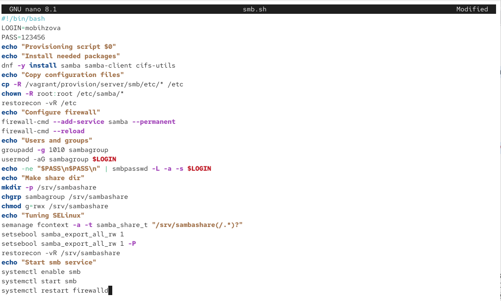

Рисунок 33: Скрипт smb.sh для автоматической настройки Samba на сервере

## Создание скриптов для автоматической настройки через Vagrant

Создана структура каталогов для хранения конфигурации Samba на клиенте (рис. 34).

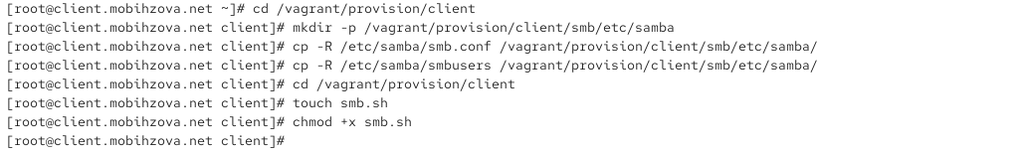

Рисунок 34: Создание каталогов и копирование конфигурационных файлов Samba на клиенте

## Создание скриптов для автоматической настройки через Vagrant

Создан скрипт автоматической настройки Samba для клиента (рис. 35).

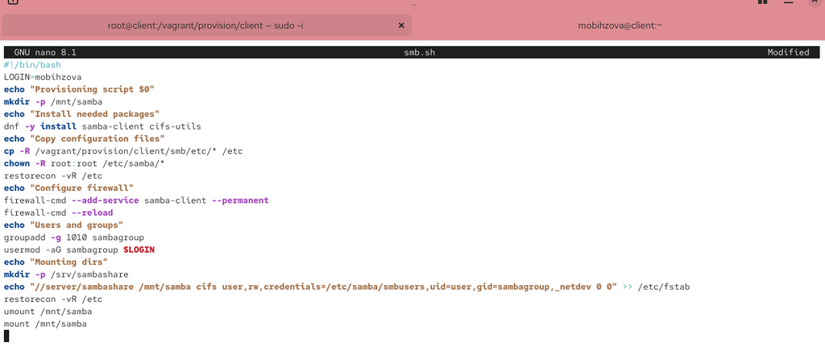

Рисунок 35: Скрипт smb.sh для автоматической настройки Samba на клиенте

## Создание скриптов для автоматической настройки через Vagrant

Добавлена конфигурация провижининга для сервера в Vagrantfile (рис. 36).

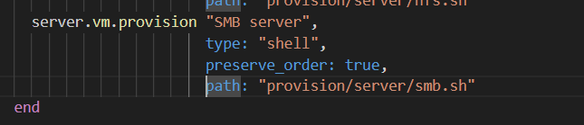

Рисунок 36: Настройка провижининга Samba сервера в Vagrantfile

## Создание скриптов для автоматической настройки через Vagrant

Добавлена конфигурация провижининга для клиента в Vagrantfile (рис. 37).

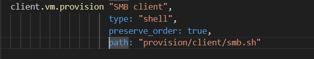

Рисунок 37: Настройка провижининга Samba клиента в Vagrantfile

# Выводы

## Выводы

В ходе выполнения данной лабораторной работы я приобрела навыки настройки доступа групп пользователей к общим ресурсам по протоколу SMB.